# A toy example of bulk RNA-seq deconvolution through ENIGMA

Weixu Wang & Jun Yao

# Prerequisites

ENIGMA is a method for deconvoluting bulk RNA-seq matrix into cell type fractions and cell type-specific expression matrices. User could freely explore the cell heterogeneity within the bulk RNA-seq samples, study the differential expression gene, cell type-specific gene co-expression module or differentiation trajectory. In this tutorial, I applied ENIGMA on NSCLC bulk RNA-seq and corresponding FACS RNA-seq collected by Gentles et al to illustrate the main steps of ENIGMA analysis.

# Construct ENIGMA object and Batch effects correction

The first step of ENIGMA require bulk RNA-seq and reference matrix to construct ENIGMA object, the ENIGMA object contains parameters and datasets for deconvolution in the following steps

```r
suppressPackageStartupMessages(library(magrittr))
suppressPackageStartupMessages(library(scater))
suppressPackageStartupMessages(library(Biobase))
suppressPackageStartupMessages(library(ENIGMA))
suppressPackageStartupMessages(library(pheatmap))

dataNSCLC <- readRDS("/mnt/data1/weixu/HiDe/dataNSCLC.rds")
ref_sc <- readRDS("/mnt/data1/weixu/HiDe/ref.rds")

#We used the third patients to generate reference
ref_sc_sub <- ref_sc[,ref_sc$PatientID %in% "3" == TRUE]
ref_sc_sub <- ref_sc_sub[,ref_sc_sub$CellFromTumor %in% "1"]
ref_sc_sub <- ref_sc_sub[,ref_sc_sub$main_celltype %in% c("Alveolar","Epi") == FALSE]

Bulk <- dataNSCLC[[5]]
Tumor <- dataNSCLC[[1]]
Immune <- dataNSCLC[[2]]
Endothelial <- dataNSCLC[[3]]
Fibroblast <- dataNSCLC[[4]]
pheno <- dataNSCLC[[6]]
# The pheno variable contain the label of each samples (LUSC vs LUAD)
names(pheno) <- colnames(Tumor)

# Create ENIGMA object
egm = create_ENIGMA(bulk = Bulk, ref = exprs(ref_sc_sub), ref_type = "single_cell", meta_ref = pData(ref_sc_sub))
```

```
## Tue Aug 10 12:07:50 2021 Reference from Single Cell RNA-seq.
```

```
## Tue Aug 10 12:07:50 2021 Obtain reference from a matrix
```

ENIGMA would automatically identify the type of reference matrix (FACS RNA-seq or scRNA-seq), and run the corresponding batch effect correction methods to generate reference matrix (S-mode and B-mode)

### S mode batch effect correction

```r
egm = batch_correct(egm, varname_cell_type = "main_celltype", n_pseudo_bulk=100)
```

```
## Tue Aug 10 12:07:51 2021 Reference is from Single Cell RNA-seq, doing batch correction in S mode.
```

```
## Tue Aug 10 12:07:51 2021 Generating pseudo bulk...
## Tue Aug 10 12:08:10 2021 Doing ComBat...
## Found 897 genes with uniform expression within a single batch (all zeros); these will not be adjusted for batch.
```

```
## Found2batches
```

```
## Adjusting for0covariate(s) or covariate level(s)
```

```
## Standardizing Data across genes
```

```
## Fitting L/S model and finding priors
```

```
## Finding parametric adjustments
```

```
## Adjusting the Data
```

```
## Tue Aug 10 12:08:14 2021 Restore reference...
```

```r
#check the reference profile
head(egm@ref)
```

```
##             B_cell          EC       Fibro    Myeloid     T cell      Tumor
## A1BG    70.6663426   13.550600   64.735641  90.194777 102.628945   4.689762
## A1CF     1.0000000    1.000000    1.000000   1.000000   1.000000   1.000000
## A2M    233.1963830 2835.731286 3242.543855 322.829441  77.674294 129.951811
## A2ML1    1.0000000    1.000000    1.000000   1.000000   1.000000   1.000000
## A4GALT  12.9801739   83.821686  147.573508   9.240916   7.070489  57.342753
## A4GNT    0.8862444    1.115529    1.052455   1.350009   1.058957   1.051578
```

To validate that after the S-mode correction, the correlation between reference and ground truth CSE expression is increased, we made comparison between reference matrix generate from S-mode correction, and reference matrix generated through directly average scRNA-seq expression.

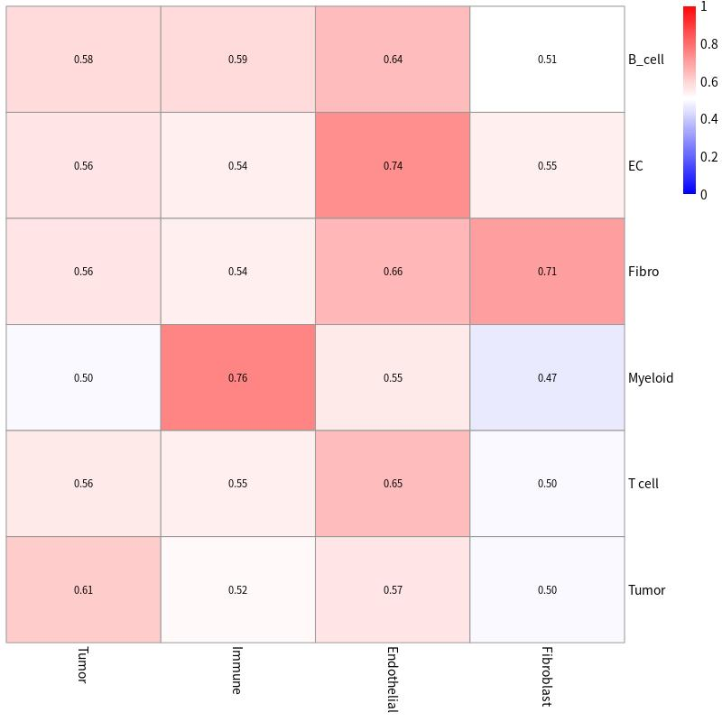

```r
# generate ground truth reference
gt <- NULL
for(K in 1:4){
 gt <- cbind(gt, rowMeans(dataNSCLC[[K]]))
}
colnames(gt) <- c("Tumor","Immune","Endothelial","Fibroblast")

ref_profile <- NULL
for(K in names(table(ref_sc_sub$main_celltype))){
 ref_profile <- cbind(ref_profile, rowMeans(exprs(ref_sc_sub)[,ref_sc_sub$main_celltype %in% K]))
}
colnames(ref_profile) <- names(table(ref_sc_sub$main_celltype))

bk <- c(seq(0,1,by=0.01))
pheatmap(cor(ref_profile[rownames(egm@ref),],gt[rownames(egm@ref),]),
         scale = "none",
         color = c(colorRampPalette(colors = c("blue","white"))(length(bk)/2),colorRampPalette(colors = c("white","red"))(length(bk)/2)),
         breaks=bk,cluster_row=FALSE,cluster_col=FALSE,display_numbers = TRUE,number_color = "black")
```

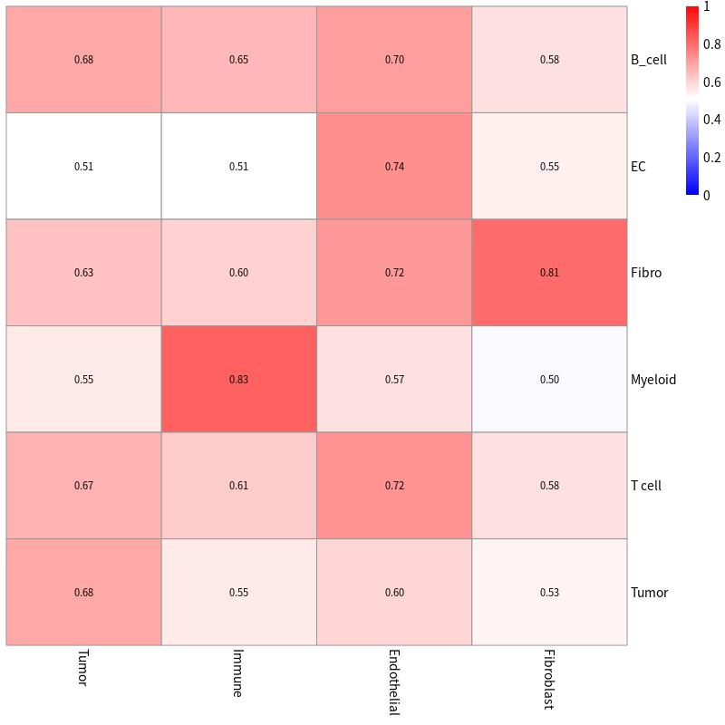

```r
pheatmap(cor(egm@ref[rownames(egm@ref),],gt[rownames(egm@ref),]),
         scale = "none",
         color = c(colorRampPalette(colors = c("blue","white"))(length(bk)/2),colorRampPalette(colors = c("white","red"))(length(bk)/2)),
         breaks=bk,cluster_row=FALSE,cluster_col=FALSE,display_numbers = TRUE,number_color = "black")
```

We could observe the increased correlation after the S-mode correlation. To reproduce our tutorial results, user also could input the reference matrix which was generated already.

```r
tmp <- readRDS("/mnt/data1/weixu/HiDe/tmp.rds")

#assign ref matrix to the ENIGMA object
egm@ref <- tmp$main_celltype
```

### B mode batch effect correction

We used FACS RNA-seq to illustrate the B-mode batch effect correction, regarding the expression profile of T3 patients as the the reference, we noted that the FACS RNA-seq is not necessarily to be generated from the same cohort with the mixture(bulk RNA-seq) but could from the independent study.

```r
B_ref = dataNSCLC[1:4] %>%
    lapply(function(x) x[,"T3"]) %>%
    do.call(cbind, .) %>%
    set_colnames( c("Tumor","Immune","Endothelial","Fibroblast") )
B_ref = B_ref[rownames(egm@ref),]

object_b_mode = create_ENIGMA(bulk = Bulk[rownames(B_ref),], ref = B_ref, ref_type = "bulk",meta_ref = as.matrix(colnames(B_ref)))
```

```
## Tue Aug 10 12:08:20 2021 Reference from FACS Bulk RNA-seq/microarray.
```

```r
object_b_mode = batch_correct(object_b_mode)
```

```
## Tue Aug 10 12:08:20 2021 Reference is from FACS Bulk RNA-seq/microarray, doing batch correction in B mode.
```

```
## Tue Aug 10 12:08:23 2021 Run B-mode to correct batch effect...
## Tue Aug 10 12:08:23 2021 Doing ComBat...
## Found 672 genes with uniform expression within a single batch (all zeros); these will not be adjusted for batch.
```

```
## Found2batches
```

```
## Adjusting for0covariate(s) or covariate level(s)
```

```
## Standardizing Data across genes
```

```
## Fitting L/S model and finding priors
```

```
## Finding parametric adjustments
```

```
## Adjusting the Data
```

```
## Tue Aug 10 12:08:23 2021 Done.
```

# Deconvolute bulk RNA-seq profile through ENIGMA

ENIGMA provides two type of regularized matrix completion methods to deconvolute bulk RNA-seq profile, L2-max norm and trace norm regularization. ENIGMA used sqrt() or log2() transformation to stablize each gene variance, make each gene expression distribution closer to the gaussian distribution.

## L2-max norm

ENIGMA first used robust linear regression to estimation cell type fractions across each sample.

```r
egm@bulk <- Bulk[rownames(tmp$main_celltype),]
egm = get_cell_proportion(egm)
```

```
## Tue Aug 10 12:08:23 2021 Calculating cell type proportion of bulk samples...
```

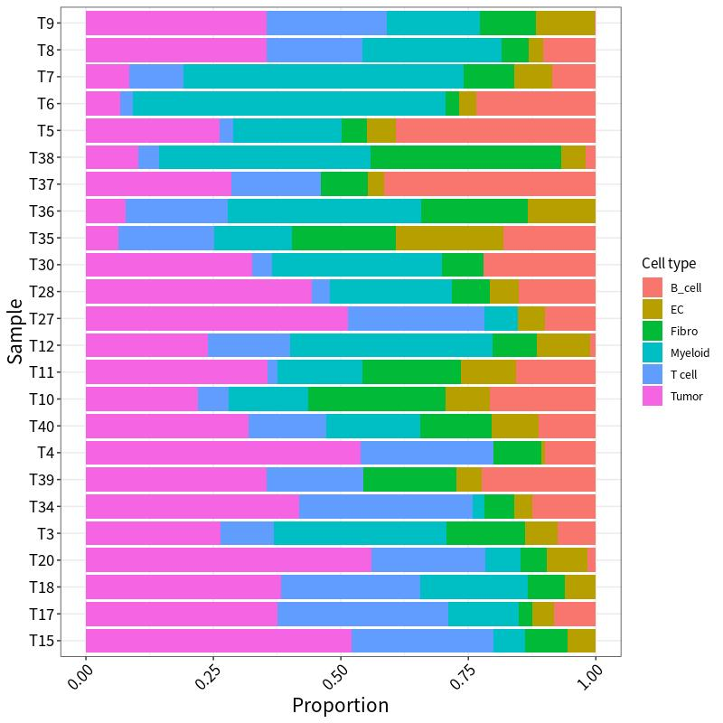

```r
plot_proportion(egm)
```

Next, we performed RNA-seq deconvolution based on L2-max norm regularized matrix completion.

```r
egm = ENIGMA_L2_max_norm(egm, epsilon=0.001, alpha=0.8,
                            beta=10000,tao_k=0.01,max.iter=1000,verbose=TRUE)
```

```
## Tue Aug 10 12:08:27 2021 Optimizing cell type specific expression profile...
##    Ratio ranges from: 4308564.013017 - 4373999.028274
##    Ratio ranges from: 97001.835711 - 133338.990223
##    Ratio ranges from: 3506.936762 - 4882.304495
##    Ratio ranges from: 144.316742 - 208.485093
##    Ratio ranges from: 7.783688 - 19.143320
##    Ratio ranges from: 0.373249 - 3.606474
##    Ratio ranges from: 0.021416 - 0.857877
##    Ratio ranges from: 0.001477 - 0.213690
##    Ratio ranges from: 0.000118 - 0.054010
##    Ratio ranges from: 0.000010 - 0.013748
##    Ratio ranges from: 0.000001 - 0.003515
##    Ratio ranges from: 0.000000 - 0.000901
## Total loss: 192259347.675211
## part1:6121083.89916561 part2:213368509.658113 part3:1544.34560495551
## Tue Aug 10 12:08:35 2021 Done...
```

**Important parameters are as follows**:

- *epsilon*: This parameter is used to determine the stop condition in CSE updating. Default: 0.001
- *alpha*: ENIGMA is a multi-objective optimization problem involve two object function, the distance function between observed bulk RNA-seq and reconstitute RNA-seq generated by weighted combination of CSE, and the distance function beween average CSE expression and cell type reference matrix. The alpha is used to determine weights of these two objects. If the alpha gets larger, the optimization attach greater importance on the the first object.
- *tao_k*: The step size of each round of gradient decent
- *max.iter*: the maximum number of iterations
- *beta*: The regularization parameter to penalize the weight (deconvoluted expression) matrices from being too large. Default: 8000

To make comparison, we performed deconvolution through bMIND

```r
#system.time({deconv = bMIND2(as.matrix(sqrt(Bulk[rownames(tmp$main_celltype),])), frac= frac_s_mode$theta, profile = sqrt(tmp$main_celltype), noRE = F,ncore=1)})
#The bMIND requires a long time to calculate CSE, input bMIND estimations results.
deconv <- readRDS("/mnt/data1/weixu/HiDe/deconv.rds")
```

We benchmarked our method with bMIND through comparing their correlation with ground truth cell type-specific expression profile

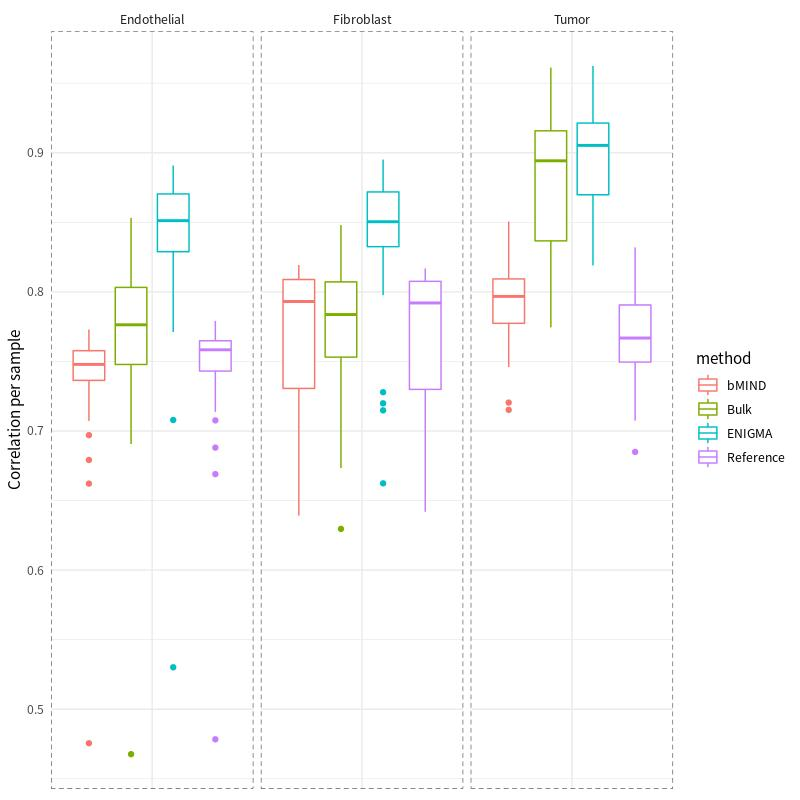

```r
L2maxNorm <- list()
L2maxNorm$expr_array <- array(0,dim=c(nrow(egm@ref),ncol(egm@bulk),6))
celltype <- colnames(egm@ref)
for(i in 1:6) L2maxNorm$expr_array[,,i] <- logcounts(egm@result_CSE)[,egm@result_CSE$cell_type == celltype[i]]

tumor.enigma <- NULL
tumor.bmind <- NULL
tumor.bulk <- NULL
tumor.ref <- NULL
for(i in 1:ncol(L2maxNorm$expr_array[,,6])){
  tumor.enigma <- c(tumor.enigma,cor(L2maxNorm$expr_array[,i,6],Tumor[rownames(tmp$main_celltype),i],method="sp"))
  tumor.bmind <- c(tumor.bmind,cor(deconv$A[,6,i],Tumor[rownames(tmp$main_celltype),i],method="sp"))
  tumor.bulk <- c(tumor.bulk,cor(Bulk[rownames(tmp$main_celltype),i],Tumor[rownames(tmp$main_celltype),i],method="sp"))
  tumor.ref <- c(tumor.ref,cor(tmp$main_celltype[,6],Tumor[rownames(tmp$main_celltype),i],method="sp"))
}
tumor_vec <- c(tumor.enigma,tumor.bmind,tumor.bulk,tumor.ref)

fibro.enigma <- NULL
fibro.bmind <- NULL
fibro.bulk <- NULL
fibro.ref <- NULL
for(i in 1:ncol(L2maxNorm$expr_array[,,3])){
  fibro.enigma <- c(fibro.enigma,cor(L2maxNorm$expr_array[,i,3],Fibroblast[rownames(tmp$main_celltype),i],method="sp"))
  fibro.bmind <- c(fibro.bmind,cor(deconv$A[,3,i],Fibroblast[rownames(tmp$main_celltype),i],method="sp"))
  fibro.bulk <- c(fibro.bulk,cor(Bulk[rownames(tmp$main_celltype),i],Fibroblast[rownames(tmp$main_celltype),i],method="sp"))
  fibro.ref <- c(fibro.ref,cor(tmp$main_celltype[,3],Fibroblast[rownames(tmp$main_celltype),i],method="sp"))
}
fibro_vec <- c(fibro.enigma,fibro.bmind,fibro.bulk,fibro.ref)

endo.enigma <- NULL
endo.bmind <- NULL
endo.bulk <- NULL
endo.ref <- NULL
for(i in 1:ncol(L2maxNorm$expr_array[,,2])){
  endo.enigma <- c(endo.enigma,cor(L2maxNorm$expr_array[,i,2],Endothelial[rownames(tmp$main_celltype),i],method="sp"))
  endo.bmind <- c(endo.bmind,cor(deconv$A[,2,i],Endothelial[rownames(tmp$main_celltype),i],method="sp"))
  endo.bulk <- c(endo.bulk,cor(Bulk[rownames(tmp$main_celltype),i],Endothelial[rownames(tmp$main_celltype),i],method="sp"))
  endo.ref <- c(endo.ref,cor(tmp$main_celltype[,2],Endothelial[rownames(tmp$main_celltype),i],method="sp"))
}
endo_vec <- c(endo.enigma,endo.bmind,endo.bulk,endo.ref)

dat <- data.frame(cor=c(tumor_vec,fibro_vec,endo_vec),celltype=c(rep("Tumor",24*4),rep("Fibroblast",24*4),rep("Endothelial",24*4)),
                  method=rep(c(rep("ENIGMA",24),rep("bMIND",24),rep("Bulk",24),rep("Reference",24)),3))
ggplot(dat, aes(x=celltype, y=cor, color=method)) +
    geom_boxplot(position=position_dodge(1))+theme_minimal()+labs(y="Correlation per sample")+ facet_grid(~celltype, scales = "free_x") +
    theme(axis.title.x = element_blank(), axis.text.x = element_blank()) +theme(panel.border = element_rect(size = 0.3, linetype = "dashed", fill = NA))
```

We could notice that CSE produced by ENIGMA show generally higher correlation with each sample than bMIND, bulk or reference matrix. We also could visualize CSE through tsne plot

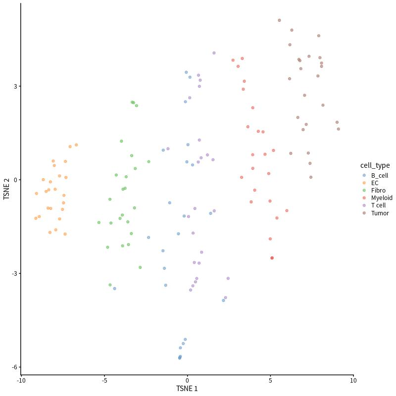

```r
##### plot TSNE and featurePlot
logcounts(egm@result_CSE) <- sqrt(logcounts(egm@result_CSE))
sce_nsclc <- runPCA(egm@result_CSE,scale=TRUE)
sce_nsclc <- runTSNE(sce_nsclc)
plotTSNE(sce_nsclc, colour_by="cell_type")
```

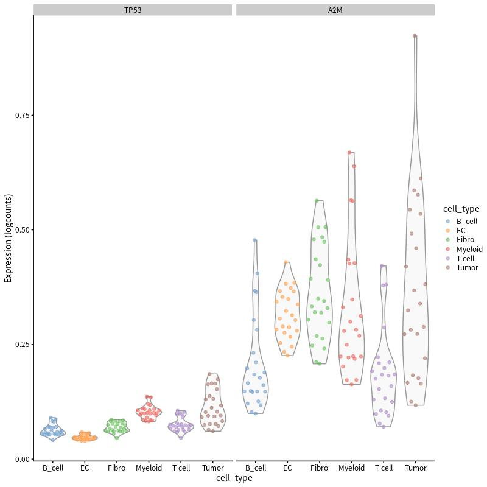

```r
plotExpression(sce_nsclc, c("TP53", "A2M"), colour_by = "cell_type", x = "cell_type")
```